# Multi-Modal Module Model Estimation Summary

Prepared by RSG, Inc.

February 10, 2022

[figure not shown]

# Introduction

This document describes the re-estimation of the VE Multimodal Module (VE-MM) using the 2017 National Household Travel Survey (2017 NHTS). The original version of the VE-MM was estimated using the 2009 NHTS.

The models described in this memo include:

- regression models used to predict household average annual daily vehicle miles traveled (AADVMT)
- models used to predict transit, bicycle, and walking trips and person miles traveled (note that these are not included in this draft)

# Estimation Data

## Data Sources

Data used to estimate the VE-MM models came from several sources. The 2017 NHTS confidential data were obtained from ORNL via FHWA. The data were provided with Census Block Group which allowed data from the EPA Smart Location Database, version 3 (SLD) to be connected to the household. Additional spatial information at the metropolitan area level were added to the data including transit revenue miles from the National Transit Database and freeway lane miles from FHWA published data.

## AADVMT and DVMT Data

The AADVMT model is estimated using the total annual miles driven by vehicles owned by the NHTS households divided by 365, instead of estimating a daily VMT model based on the reported travel during the survey day. The distributions of those travel amounts differs in the data.

In particular there are a lot of “zero days” in the survey data for the survey day. There are also more very long days in the survey data with more than 200 miles of travel reported. With the averaging over the year that takes place by using AADVMT, a lot of the day to day variability within a household’s travel is removed. The final chart compares the none-zero day distribution and other than the extremes at the low end and high end of the distribution, the distributions are reasonably comparable.

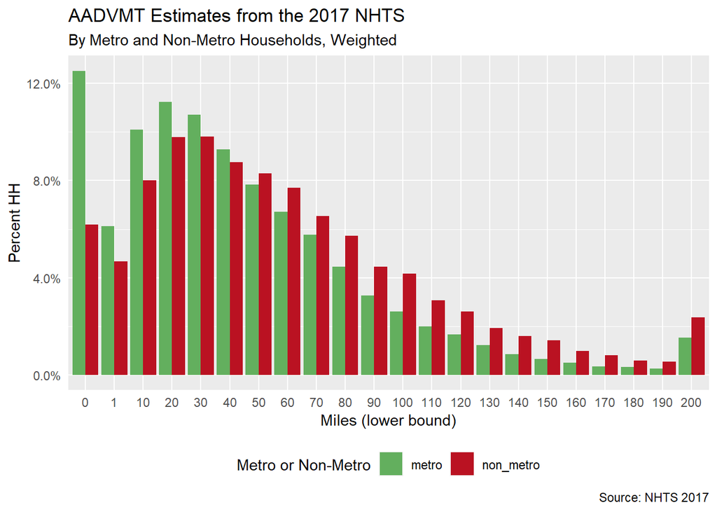

Figure 1: Distribution of AADVMT per Household in the 2017 NHTS

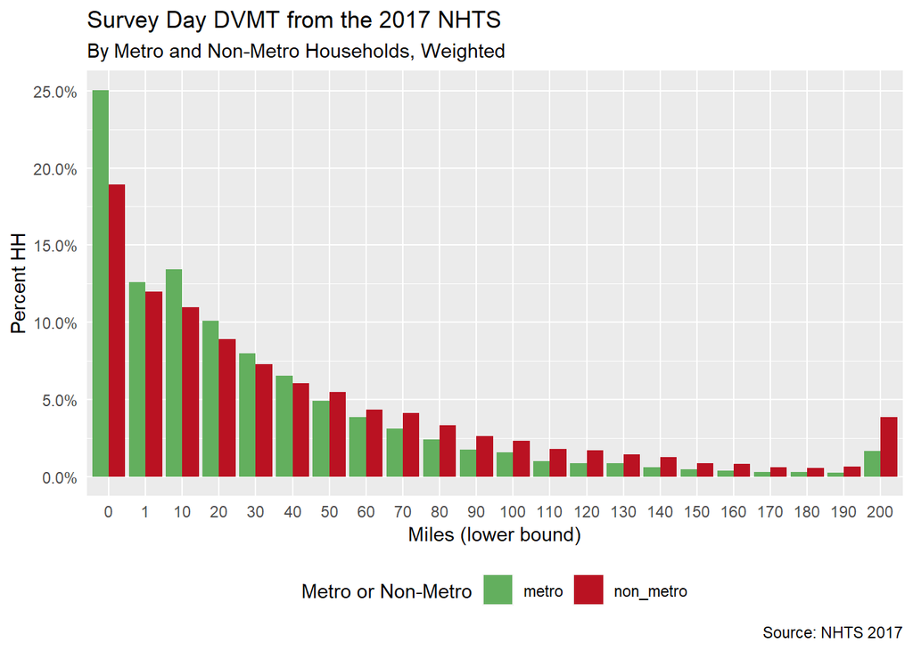

Figure 2: Distribution of Survey Day DVMT per Household in the 2017 NHTS

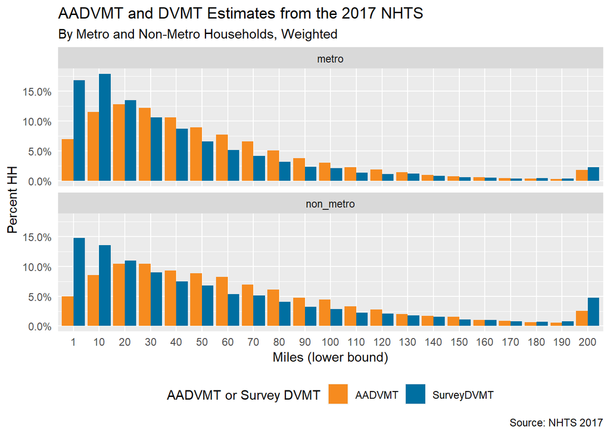

Figure 3: Comparison between AADVMT and Survey Day DVMT per Household in the 2017 NHTS

## Population Density (D1B)

One of the important explanatory variables for household AADVMT is the population density of the neighborhood in which the household resides. The 2017 NHTS data were linked to the SLD and the D1B variable, which contains the Census Block Group population density in units of persons per acre. The ranges of density varies significantly in the sample of NHTS households. As is expected, most non-metro households live in low density areas while the range of densities for metropolitan households is generally higher but covers several orders of magnitude. The following box plot, plotted on a log scale shows the distribution of households by population density.

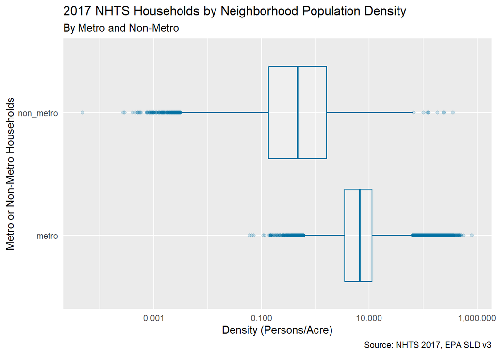

Figure 4: Distribution of Households in the 2017 NHTS by Population Density

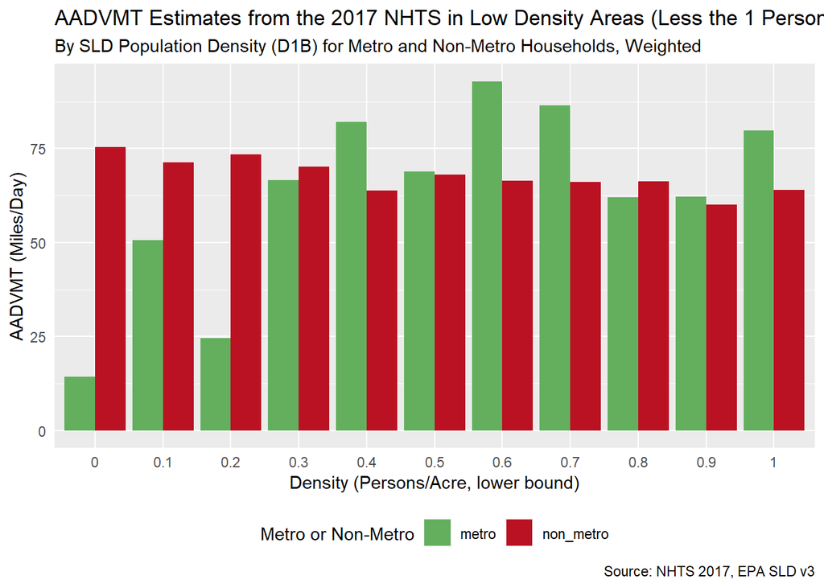

Figure 5: 2017 NHTS AADVMT by Density for Households in Low Density Neighborhoods

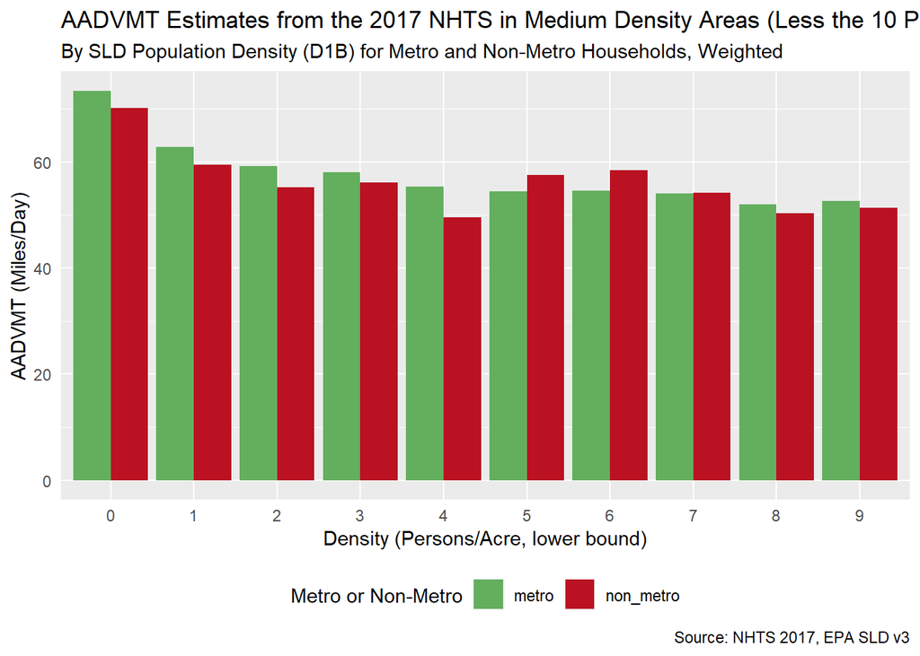

Figure 6: 2017 NHTS AADVMT by Density for Households in Medium Density Neighborhoods

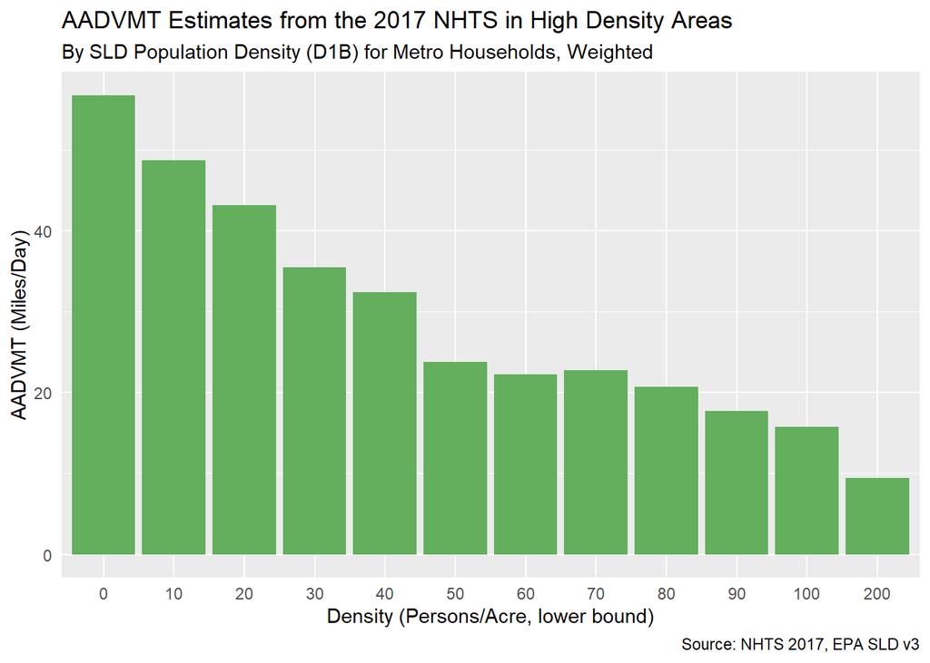

Figure 7: 2017 NHTS AADVMT by Density for Households in High Density Neighborhoods

## Household Income

Household income has a positive impact on the amount of travel a household makes, with higher income households traveling more. The first chart shows the distribution of income levels amongst the households in the 2017 NHTS sample. The second charts shows the relationship between AADVMT and household income and shows shows a clear postiive trend for both metropolitan and non-metropolitan households.

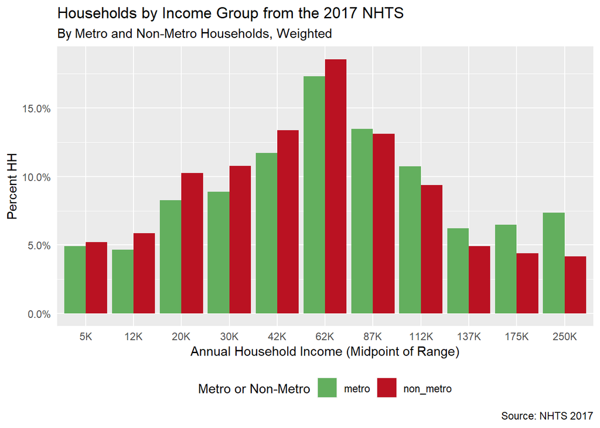

Figure 8: Distribution of Households in the 2017 NHTS by Household Income

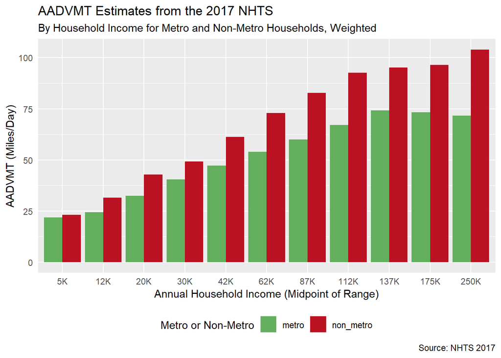

Figure 9: 2017 NHTS AADVMT by Household Income

## Household Size

Household size has a positive impact on the amount of travel a household makes, with larger households traveling more. The first chart shows the distribution of household size amongst the households in the 2017 NHTS sample. The second charts shows the relationship between AADVMT and household size and shows shows a clear postiive trend for both metropolitan and non-metropolitan households.

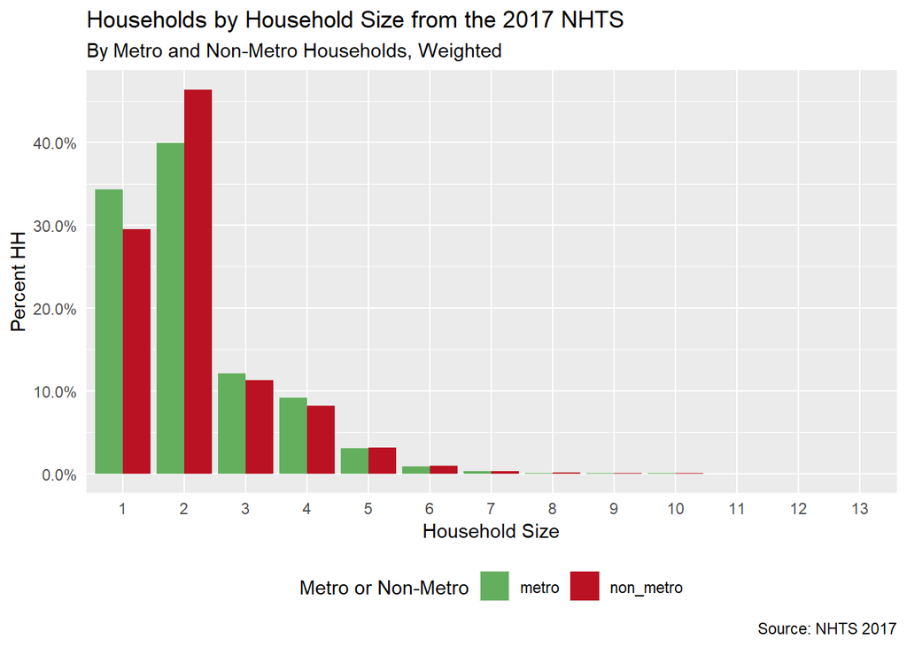

Figure 10: Distribution of Households in the 2017 NHTS by Household Size

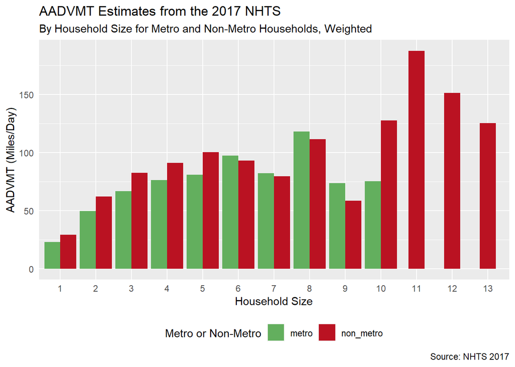

Figure 11: 2017 NHTS AADVMT by Household Size

## Household life cycle stage

The household’s life cycle stage, i.e., whether the household is a single person, a couple without children, a couple with children, or older “empty nesters” influences the amount of travel a household makes. Multi person household make more travel and adding children to the household causes a further moderate increase in the amount of travel. The first chart shows the distribution of life cycle stage amongst the households in the 2017 NHTS sample. The second charts shows the relationship between AADVMT and household life cycle stage for both metropolitan and non-metropolitan households.

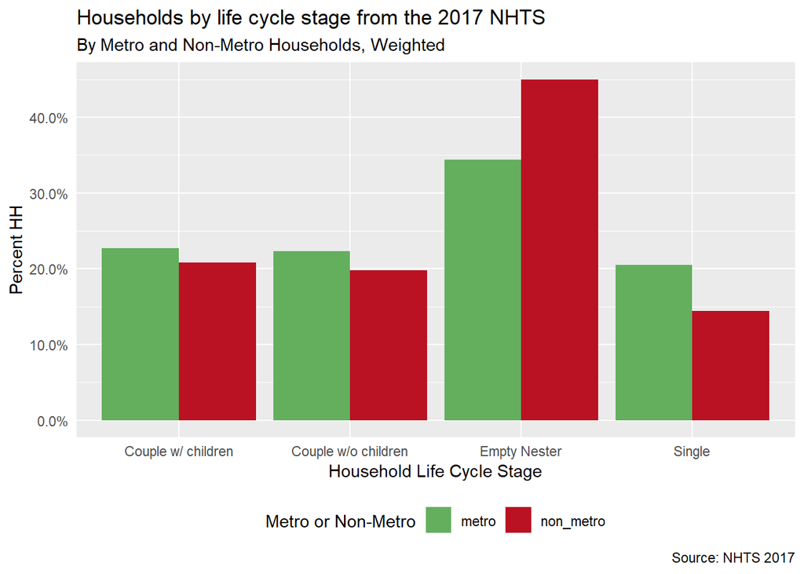

Figure 12: Distribution of Households in the 2017 NHTS by Household Life Cycle Stage

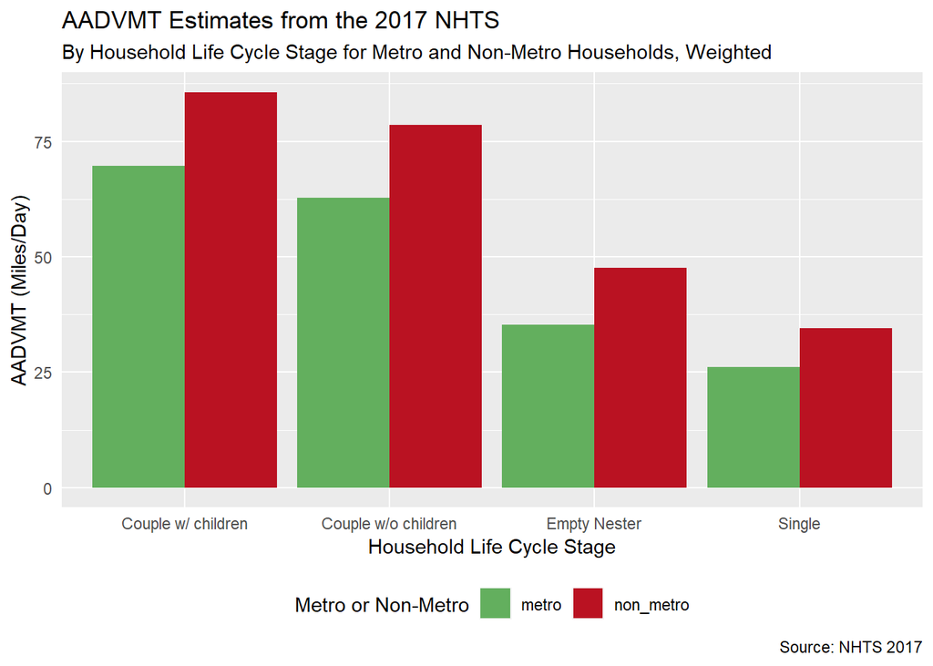

Figure 13: 2017 NHTS AADVMT by Household Life Cycle Stage

## Number of Workers

The number of workers in the household positively impacts the amount of travel a household makes. With each additional worker in the household, the household make more travel. The first chart shows the distribution of number of workers per households amongst the households in the 2017 NHTS sample. The second charts shows the relationship between AADVMT and number of workers per household for both metropolitan and non-metropolitan households.

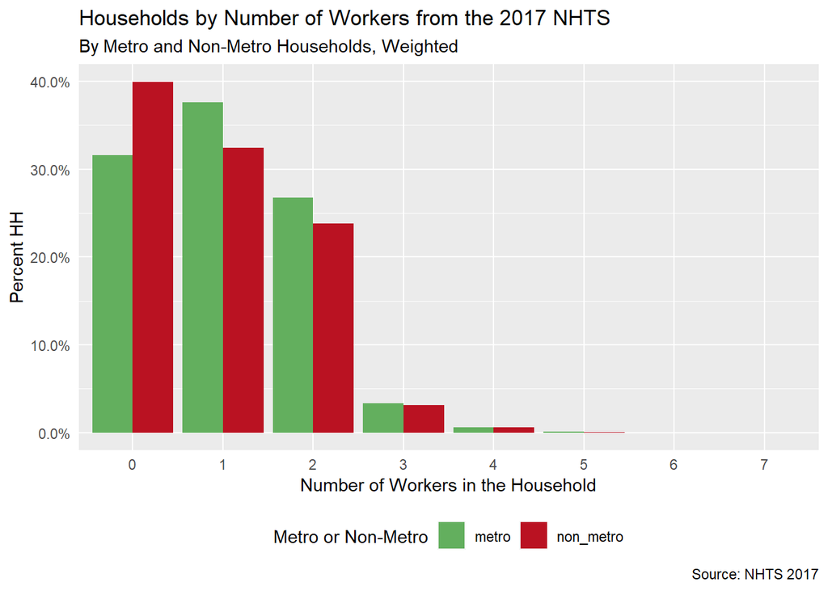

Figure 14: Distribution of Households in the 2017 NHTS by Number of Workers in the Household

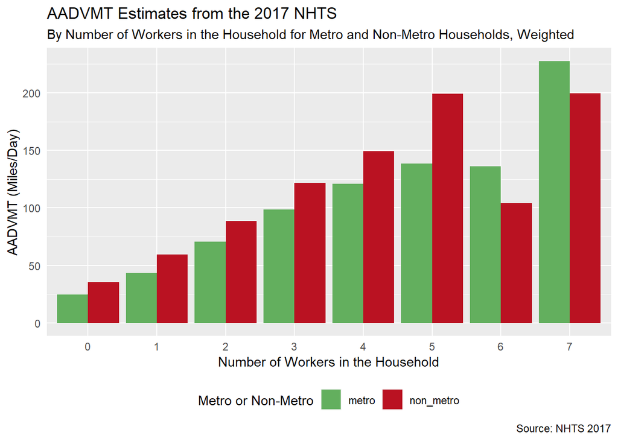

Figure 15: 2017 NHTS AADVMT by Number of Workers in the Household

## Number of Drivers

The number of drivers in the household positively impacts the amount of travel a household makes. With each additional driver in the household, the household make more travel. The first chart shows the distribution of number of drivers per households amongst the households in the 2017 NHTS sample. The second charts shows the relationship between AADVMT and number of drivers per household for both metropolitan and non-metropolitan households.

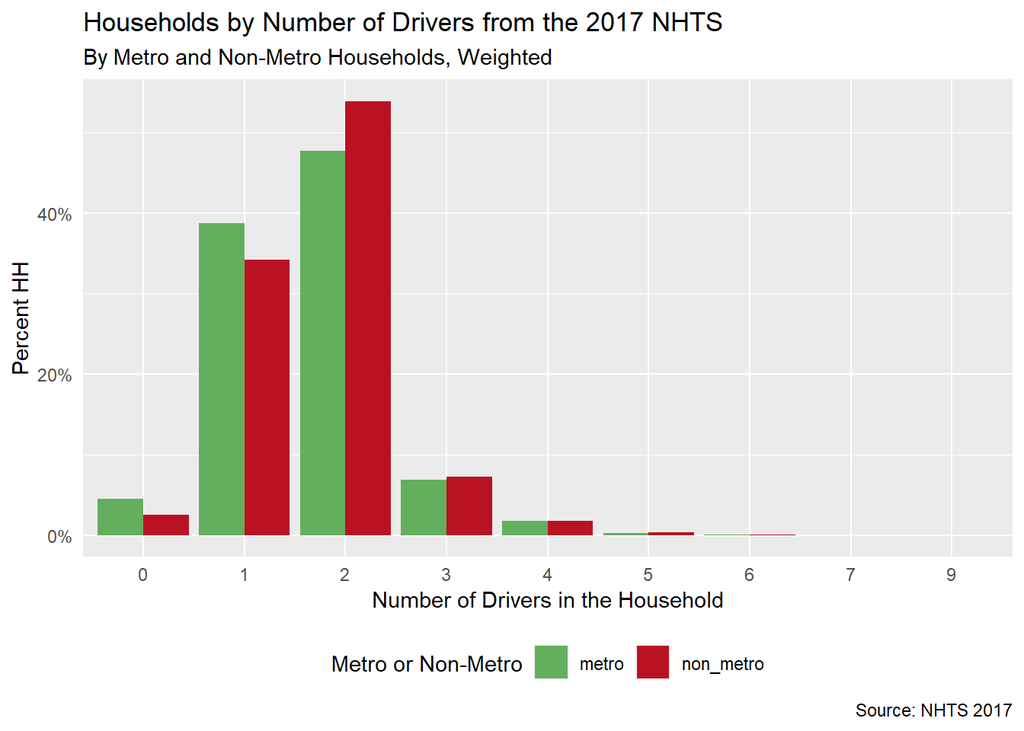

Figure 16: Distribution of Households in the 2017 NHTS by Number of Drivers in the Household

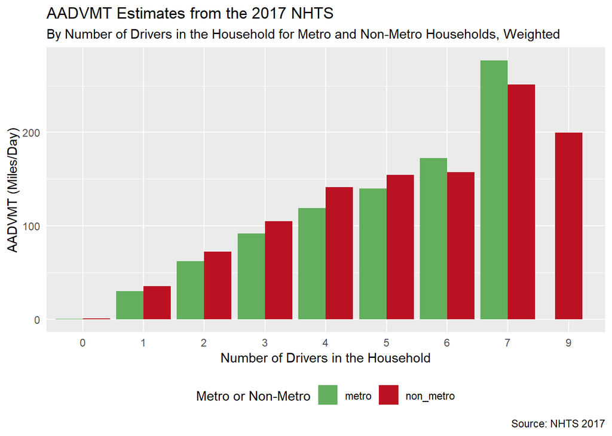

Figure 17: 2017 NHTS AADVMT by Number of Drivers in the Household

# Model Estimation

## 2017 NHTS AADVMT Model

The following table shows the AADVMT model estimated using the 2017 NHTS for Metro areas and Non-Metro area.

**Regression model summary for 2017 AADVMT Model for Metro Areas and Non-Metro Areas**

|  | *Dependent variable:* |  |
| --- | --- | --- |
|  | AADVMT |  |
|  | NONMETRO | METRO |
|  | (1) | (2) |
| Drivers | 0.758*** (0.009) | 0.784*** (0.006) |
| HhSize | 0.018** (0.007) |  |
| Workers | 0.157*** (0.007) | 0.086*** (0.006) |
| CENSUS_RNE | -0.040*** (0.014) | -0.077*** (0.012) |
| CENSUS_RS | 0.072*** (0.010) | 0.003 (0.010) |
| CENSUS_RW | -0.162*** (0.013) | -0.091*** (0.011) |
| FwyLaneMiPC |  | 41.259*** (12.908) |
| LogIncome | 0.268*** (0.005) | 0.154*** (0.004) |
| Age0to14 | 0.038*** (0.009) | 0.067*** (0.007) |
| Age65Plus | -0.037*** (0.008) | -0.062*** (0.008) |
| log1p(VehPerDriver) | 2.957*** (0.017) | 3.365*** (0.016) |
| LifeCycleCouple w/o children | -0.084*** (0.015) | -0.029** (0.012) |
| LifeCycleEmpty Nester | -0.279*** (0.019) | -0.362*** (0.016) |
| LifeCycleSingle | -0.285*** (0.020) | -0.304*** (0.014) |
| D1B | -0.013*** (0.002) | -0.002*** (0.0001) |
| D2A_EPHHM | -0.240*** (0.022) |  |
| D1B:D2A_EPHHM | 0.015*** (0.004) |  |
| D2A_WRKEMP |  | -0.0001 (0.0001) |
| D3bpo4 |  | -0.001*** (0.0001) |
| TranRevMiPC:D4c |  | -0.048*** (0.003) |
| Constant | -1.958*** (0.058) | -1.155*** (0.045) |
| Observations | 54,586 | 69,374 |
| R<sup>2</sup> | 0.665 | 0.721 |
| Adjusted R<sup>2</sup> | 0.665 | 0.720 |
| Residual Std. Error | 0.880 (df = 54569) | 1.036 (df = 69356) |
| F Statistic | 6,767.002*** (df = 16; 54569) | 10,518.910*** (df = 17; 69356) |
| *Note:* | p<0.1; p<0.05; p<0.01 |  |

The following tables compare the AADVMT models estimated using the 2009 and 2017 NHTS.

This first comparison is between 2009 and 2017 AADVMT Models for Metro areas.

| VarName | NHTS2009 | NHTS2017 | Ratio |
| --- | --- | --- | --- |
| (Intercept) | -1.333 | -1.155 | 0.866 |
| Age0to14 | 0.107 | 0.067 | 0.626 |
| Age65Plus | -0.075 | -0.062 | 0.837 |
| CENSUS_RNE | -0.109 | -0.077 | 0.707 |
| CENSUS_RS | 0.051 | 0.003 | 0.061 |
| CENSUS_RW | -0.092 | -0.091 | 0.987 |
| D1B | -0.003 | -0.002 | 0.591 |
| D2A_WRKEMP | 0.000 | 0.000 | 0.310 |
| D3bpo4 | -0.001 | -0.001 | 0.609 |
| Drivers | 0.705 | 0.784 | 1.113 |
| FwyLaneMiPC | 101.341 | 41.259 | 0.407 |
| LifeCycleCouple w/o children | -0.036 | -0.029 | 0.808 |
| LifeCycleEmpty Nester | -0.256 | -0.362 | 1.412 |
| LifeCycleSingle | -0.234 | -0.304 | 1.299 |
| LogIncome | 0.268 | 0.154 | 0.572 |
| TranRevMiPC:D4c | -0.020 | -0.048 | 2.415 |
| Workers | 0.186 | 0.086 | 0.464 |
| log1p(VehPerDriver) | 1.794 | 3.365 | 1.876 |

This second comparison is between 2009 and 2017 AADVMT Models for Non-Metro areas.

| VarName | NHTS2009 | NHTS2017 | Ratio |
| --- | --- | --- | --- |
| (Intercept) | -1.416 | -1.958 | 1.382 |
| Age0to14 | 0.102 | 0.038 | 0.374 |
| Age65Plus | -0.077 | -0.037 | 0.483 |
| CENSUS_RNE | -0.112 | -0.040 | 0.358 |
| CENSUS_RS | 0.058 | 0.072 | 1.236 |
| CENSUS_RW | -0.176 | -0.162 | 0.921 |
| D1B | -0.008 | -0.013 | 1.611 |
| D1B:D2A_EPHHM | -0.027 | 0.015 | -0.581 |
| D2A_EPHHM | -0.084 | -0.240 | 2.840 |
| Drivers | 0.744 | 0.758 | 1.019 |
| HhSize | 0.017 | 0.018 | 1.048 |
| LifeCycleCouple w/o children | -0.013 | -0.084 | 6.236 |
| LifeCycleEmpty Nester | -0.208 | -0.279 | 1.338 |
| LifeCycleSingle | -0.216 | -0.285 | 1.317 |
| LogIncome | 0.288 | 0.268 | 0.933 |
| Workers | 0.177 | 0.157 | 0.885 |
| log1p(VehPerDriver) | 1.852 | 2.957 | 1.596 |

# Model Prediction Testing

| Metro or Non-Metro | NHTS2017 AADVMT/HH | Model AADVMT/HH | Ratio Model/NHTS2017 |
| --- | --- | --- | --- |
| metro | 53.90 | 45.98 | 0.85 |
| non_metro | 66.12 | 58.43 | 0.88 |

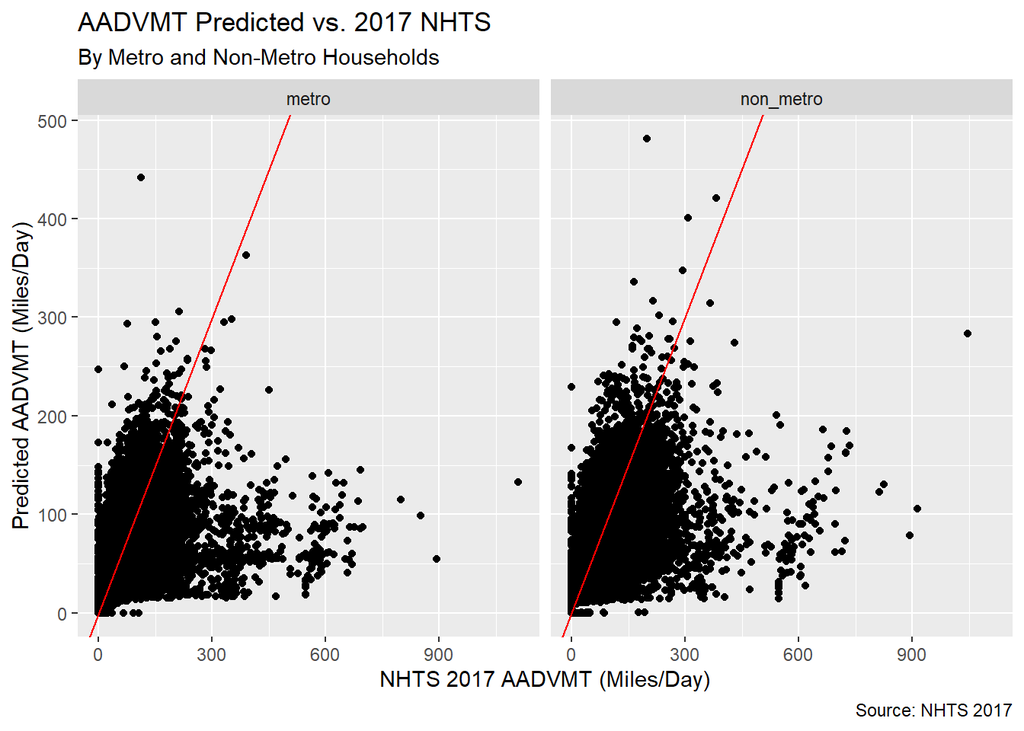

Figure 18: Scatterplot of Model Prediction vs. 2017 NHTS Data

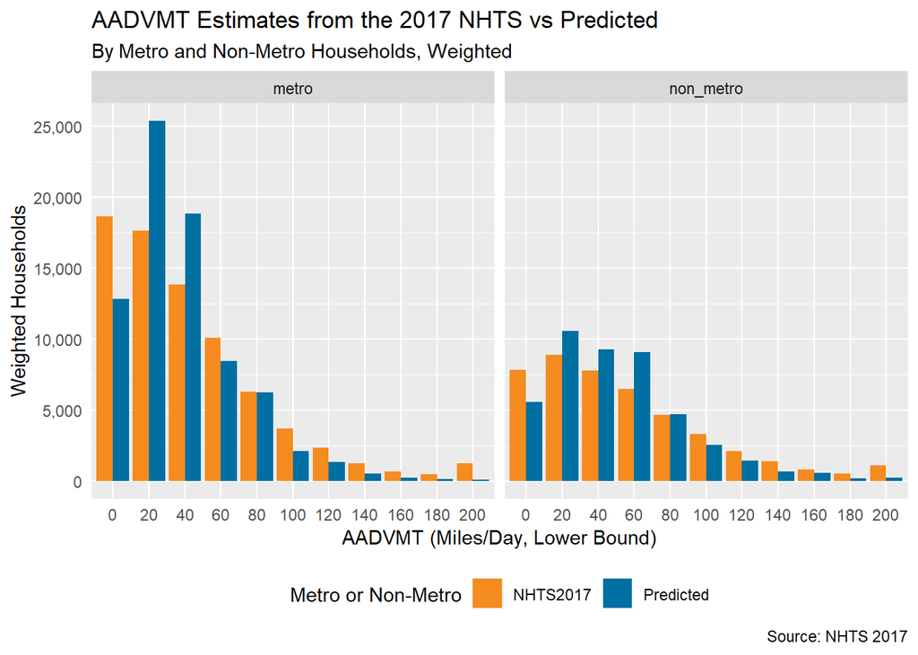

Figure 19: Households by DVMT Bins, Model Prediction vs. 2017 NHTS Data

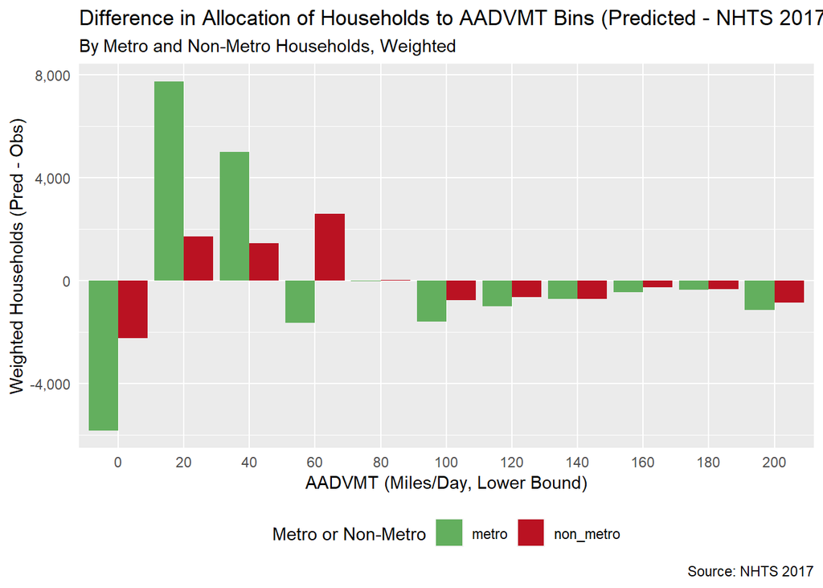

Figure 20: Difference in Households in DVMT Bins (Model Prediction - 2017 NHTS Data)

| HH Income | Metro Obs AADVMT/HH | Non-Metro Obs AADVMT/HH | Metro Model AADVMT/HH | Non-Metro Model AADVMT/HH | Metro Ratio Model/Obs | Non-Metro Ratio Model/Obs |
| --- | --- | --- | --- | --- | --- | --- |
| 5000 | 30.87 | 27.38 | 20.54 | 19.11 | 0.67 | 0.70 |
| 12500 | 30.51 | 31.69 | 23.96 | 25.16 | 0.79 | 0.79 |
| 19999 | 35.55 | 43.00 | 29.23 | 34.21 | 0.82 | 0.80 |
| 30000 | 41.83 | 49.25 | 33.94 | 42.54 | 0.81 | 0.86 |
| 42499 | 47.83 | 61.31 | 39.30 | 53.32 | 0.82 | 0.87 |
| 62500 | 54.32 | 72.96 | 45.74 | 64.79 | 0.84 | 0.89 |
| 87500 | 60.37 | 82.77 | 51.79 | 75.87 | 0.86 | 0.92 |
| 112500 | 67.53 | 92.56 | 60.38 | 81.92 | 0.89 | 0.89 |
| 137500 | 74.33 | 95.09 | 63.08 | 88.57 | 0.85 | 0.93 |
| 174999 | 73.59 | 96.58 | 66.60 | 90.34 | 0.90 | 0.94 |
| 249999 | 72.17 | 103.94 | 68.28 | 100.08 | 0.95 | 0.96 |

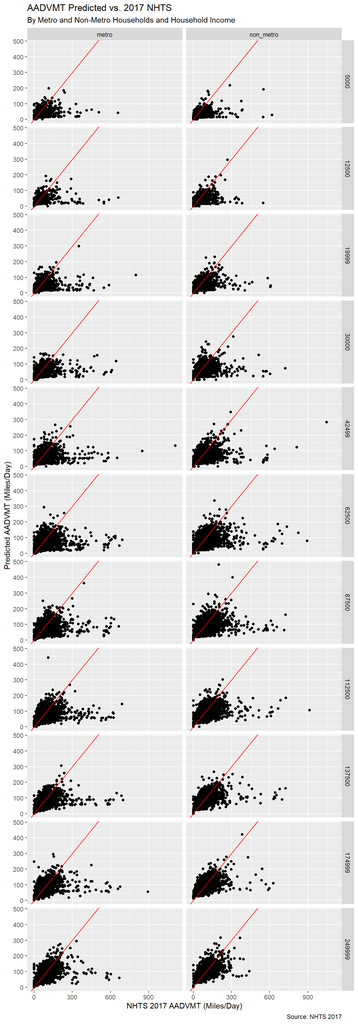

Figure 21: Scatterplot of Model Prediction vs. 2017 NHTS Data by Income

| D1B Group | Metro Obs AADVMT/HH | Non-Metro Obs AADVMT/HH | Metro Model AADVMT/HH | Non-Metro Model AADVMT/HH | Metro Ratio Model/Obs | Non-Metro Ratio Model/Obs |
| --- | --- | --- | --- | --- | --- | --- |
| 0 | 58.83 | 66.53 | 50.94 | 58.81 | 0.87 | 0.88 |
| 10 | 51.61 | 54.26 | 43.17 | 47.42 | 0.84 | 0.87 |
| 20 | 46.68 | 53.35 | 37.48 | 41.80 | 0.80 | 0.78 |
| 30 | 38.88 | 37.64 | 30.45 | 53.59 | 0.78 | 1.42 |
| 40 | 36.38 | 14.21 | 29.33 | 24.08 | 0.81 | 1.69 |
| 50 | 28.09 | 5.28 | 24.63 | 16.74 | 0.88 | 3.17 |
| 60 | 25.30 | 23.41 | 24.36 | 14.39 | 0.96 | 0.61 |
| 70 | 29.50 | 0.00 | 21.07 | 0.00 | 0.71 | 0.00 |
| 80 | 24.21 | 0.00 | 19.71 | 0.00 | 0.81 | 0.00 |
| 90 | 24.18 | 0.00 | 22.19 | 0.00 | 0.92 | 0.00 |
| 100 | 21.89 | 23.59 | 16.13 | 16.47 | 0.74 | 0.70 |
| 200 | 14.64 | 86.26 | 9.21 | 37.77 | 0.63 | 0.44 |

| HH Size | Metro Obs AADVMT/HH | Non-Metro Obs AADVMT/HH | Metro Model AADVMT/HH | Non-Metro Model AADVMT/HH | Metro Ratio Model/Obs | Non-Metro Ratio Model/Obs |
| --- | --- | --- | --- | --- | --- | --- |
| 1 | 27.36 | 31.28 | 23.95 | 28.43 | 0.88 | 0.91 |
| 2 | 50.77 | 62.53 | 42.55 | 54.01 | 0.84 | 0.86 |
| 3 | 67.21 | 82.67 | 55.67 | 72.02 | 0.83 | 0.87 |
| 4 | 76.25 | 91.29 | 65.83 | 80.99 | 0.86 | 0.89 |
| 5 | 81.20 | 98.47 | 73.33 | 87.05 | 0.90 | 0.88 |
| 6 | 97.16 | 93.07 | 82.20 | 92.50 | 0.85 | 0.99 |
| 7 | 82.20 | 76.61 | 71.81 | 80.83 | 0.87 | 1.06 |
| 8 | 107.79 | 111.41 | 104.64 | 117.05 | 0.97 | 1.05 |
| 9 | 71.10 | 63.56 | 66.61 | 78.50 | 0.94 | 1.24 |
| 10 | 75.35 | 127.70 | 82.03 | 105.63 | 1.09 | 0.83 |
| 11 | 0.00 | 187.66 | 0.00 | 153.39 | 0.00 | 0.82 |
| 12 | 0.00 | 151.29 | 0.00 | 215.22 | 0.00 | 1.42 |
| 13 | 0.00 | 125.29 | 0.00 | 103.36 | 0.00 | 0.83 |

| Workers | Metro Obs AADVMT/HH | Non-Metro Obs AADVMT/HH | Metro Model AADVMT/HH | Non-Metro Model AADVMT/HH | Metro Ratio Model/Obs | Non-Metro Ratio Model/Obs |
| --- | --- | --- | --- | --- | --- | --- |
| 0 | 30.04 | 37.18 | 25.90 | 32.38 | 0.86 | 0.87 |
| 1 | 44.35 | 59.54 | 37.24 | 50.85 | 0.84 | 0.85 |
| 2 | 70.91 | 88.21 | 58.98 | 77.34 | 0.83 | 0.88 |
| 3 | 98.52 | 122.63 | 90.11 | 118.55 | 0.91 | 0.97 |
| 4 | 122.71 | 148.62 | 121.23 | 155.66 | 0.99 | 1.05 |
| 5 | 132.48 | 198.44 | 161.58 | 211.56 | 1.22 | 1.07 |
| 6 | 136.18 | 104.34 | 190.20 | 236.00 | 1.40 | 2.26 |
| 7 | 227.64 | 199.52 | 197.12 | 481.28 | 0.87 | 2.41 |

| Drivers | Metro Obs AADVMT/HH | Non-Metro Obs AADVMT/HH | Metro Model AADVMT/HH | Non-Metro Model AADVMT/HH | Metro Ratio Model/Obs | Non-Metro Ratio Model/Obs |
| --- | --- | --- | --- | --- | --- | --- |
| 0 | 0.30 | 1.24 | 0.04 | 0.16 | 0.14 | 0.13 |
| 1 | 30.39 | 35.51 | 26.68 | 32.39 | 0.88 | 0.91 |
| 2 | 62.55 | 72.77 | 51.12 | 61.63 | 0.82 | 0.85 |
| 3 | 91.76 | 104.19 | 78.89 | 94.19 | 0.86 | 0.90 |
| 4 | 118.98 | 142.21 | 115.42 | 141.34 | 0.97 | 0.99 |
| 5 | 139.49 | 154.35 | 159.20 | 181.42 | 1.14 | 1.18 |
| 6 | 170.99 | 156.87 | 204.70 | 225.64 | 1.20 | 1.44 |
| 7 | 294.84 | 251.42 | 280.22 | 272.84 | 0.95 | 1.09 |
| 9 | 0.00 | 199.52 | 0.00 | 481.28 | 0.00 | 2.41 |

# Model Application Testing